# Generalised Additive Models

- Show All Code
- Hide All Code
- View Source

Author

Cormac Monaghan

Published

February 22, 2024

```r
set.seed(2468) # Reproducibility

library(dplyr)
library(mgcv) # For working with GAMs

path_data <- "./01__Data/02__Processed/"
path_graphics <- "./02__Models/Results/Figures/03__GAM/"

health_data <- readxl::read_xlsx(here::here(path_data, "Health_HRS.xlsx"))

health_data <- health_data %>%
  dplyr::mutate(Education_fac = factor(case_when(
    Education == 0 ~ "No degree",
    Education == 1 ~ "GED",
    Education == 2 ~ "High School",
    Education == 3 ~ "College (2yrs)",
    Education == 4 ~ "College (4yrs)",
    Education == 5 ~ "Masters",
    Education == 6 ~ "Professional Degree"),
    levels = c(
      "No degree", "GED", "High School", "College (2yrs)","College (4yrs)", "Masters", "Professional Degree")),
    .after = Education)
```

# Generalised Additive Models

Generalized additive models (GAMs) are a type of statistical model that can capture complex and non-linear relationships between predictor variables and a response variable. The GAM is a flexible extension of the generalized linear model (GLM). GAMs extend the framework of generalized linear models (GLMs) by allowing the response variable to depend on smooth functions of the predictors, rather than on linear combinations of them. This gives GAMs more flexibility and accuracy than GLMs when modeling data that exhibits non-linearity, heteroscedasticity, or interactions. Similar to the GLM, a link function is used to establish the relationship between the response and explanatory variables in the GAM. However, the linear predictor of the GLM is now replaced by a more general additive predictor of the form $\sum f_1(x_i)$, where $f_i(x_i)$ are unspecified nonparametric functions

A GAM can be written in the form:

$$g(\mu) = \alpha + f_1(x_1) + f_2(x_2) + ... + f_i(x_i)$$

where $\mu = E(Y \thicksim X_1, X_2, \dots, X_i), Y_i$ is a response variable, $g(\mu)$ is a link function determined by the distribution form of the response variable, $\alpha$ is an intercept term, and $f_1, \dots, f_i$ are smooth functions of the predictor variables $x_i$. The smooth functions $f_i$ can be estimated by various methods, such as splines, kernels, or local regression. GAMs can also include parametric terms, such as linear or polynomial terms, or random effects, to account for additional sources of variation or correlation in the data.

# HRS Dataset

The HRS, administered by the Institute for Social Research at the University of Michigan, is a longitudinal panel study that predominantly focuses on adults over the age of 50. The study collects, biennially, detailed information pertaining to respondent’s physical, cognitive, financial, employment, family, and psychosocial conditions. Similarly, in each wave, experimental modules are administered at the end of the core interview. These modules consist of concise questionnaires designed to explore new topics or supplement existing core survey data. However, each respondent only receives one experimental module, and the sample sizes for each module constitute approximately 10% of the core sample.

## Health Problems and Health Protection

Within the HRS dataset, we have a data on 9 different health problems and 6 different health protective behaviors. These have been coded as either $0$ (not present/not done) or $1$ (present/done).

```r
health_data %>%
  select(
    ID, Age, Gender, Education, College, Back_pain:Alcohol, Smoker_current,
    Blood_pressure:Dental_visit_2_years, Total_depression) %>%
  rename(Drinking = "Alcohol", Smoker = "Smoker_current") %>%
  head(n = 4) %>%
  kableExtra::kbl(align = 'c') %>%
  kableExtra::kable_styling(
    full_width = FALSE,
    bootstrap_options = c("striped", "hover", "condensed", "responsive"))
```

| ID | Age | Gender | Education | College | Back_pain | Headache | Fatigue | Drinking | Smoker | Blood_pressure | Diabetes | Cholesterol | Heart_condition | Prostate_exam | Mammogram | Cholesterol_screening | Pap_smear | Flu_shot | Dental_visit_2_years | Total_depression |
| --- | --- | --- | --- | --- | --- | --- | --- | --- | --- | --- | --- | --- | --- | --- | --- | --- | --- | --- | --- | --- |
| 1 | 76 | 1 | 4 | 1 | 0 | 0 | 0 | 1 | NA | 0 | 1 | 1 | 0 | NA | 1 | 1 | 0 | 1 | 1 | 0 |
| 2 | 80 | 1 | 5 | 1 | 1 | 0 | 0 | 0 | NA | 0 | 0 | 0 | 0 | NA | 1 | 1 | 0 | 1 | 1 | 3 |
| 3 | 89 | 0 | 4 | 1 | 0 | 0 | 0 | 0 | NA | 1 | 0 | 0 | 0 | 1 | NA | 1 | NA | 1 | 1 | 2 |
| 4 | 88 | 1 | 0 | 0 | 0 | 0 | 0 | 0 | 0 | 1 | 1 | 0 | 0 | NA | 0 | 1 | 0 | 1 | 0 | 1 |

## Procrastination

During the 2020 wave of data collection, one of these experimental modules included a module termed “long-term care insurance procrastination”. This module was split into two parts with the second half incorporating a procrastination measure with the aim of investigating how procrastination influences decision-making in later life.

```r
health_data %>%
  select(ID, Procras_1:Procras_12, Total_procrastination) %>%
  head(n = 4) %>%
  kableExtra::kbl(align = 'c') %>%
  kableExtra::kable_styling(
    full_width = FALSE,
    bootstrap_options = c("striped", "hover", "condensed", "responsive"))
```

| ID | Procras_1 | Procras_2 | Procras_3 | Procras_4 | Procras_5 | Procras_6 | Procras_7 | Procras_8 | Procras_9 | Procras_10 | Procras_11 | Procras_12 | Total_procrastination |
| --- | --- | --- | --- | --- | --- | --- | --- | --- | --- | --- | --- | --- | --- |
| 1 | 2 | 2 | 2 | 2 | 2 | 2 | 2 | 2 | 2 | 1 | 1 | 2 | 22 |
| 2 | 3 | 3 | 4 | 4 | 4 | 4 | 3 | 3 | 4 | 4 | 3 | 2 | 41 |
| 3 | NA | NA | NA | NA | NA | 3 | 2 | NA | NA | NA | NA | NA | 5 |
| 4 | 5 | 5 | 5 | 5 | 5 | 5 | 5 | 5 | 5 | 5 | 5 | 5 | 60 |

# Checking for Interactions

For each of the health variables a logistic regression is fitted to assess for interaction effects - the results of this preliminary analysis indicated that the following variables had an interaction effect

- Prostate Exam $\rightarrow$ Procrastination:Depression
- Pap Smear $\rightarrow$ Depression:Age
- Dental Visits $\rightarrow$ Procrastination:Age
- Cholesterol Screening $\rightarrow$ Depression:Age

```r
# Fitting Models
prostate_fit <- glm(
  Prostate_exam ~ (Total_procrastination + Total_depression + Age)^2 + Education,
  data = health_data, family = "binomial")

pap_fit <- glm(
  Pap_smear ~ (Total_procrastination + Total_depression + Age)^2 + Education,
  data = health_data, family = "binomial")

dental_fit <- glm(
  Dental_visit_2_years ~ (Total_procrastination + Total_depression + Age)^2 + Education,
  data = health_data, family = "binomial")

cholesterol_fit <- glm(
  Cholesterol_screening ~ (Total_procrastination + Total_depression + Age)^2 + Education,
  data = health_data, family = "binomial")

# Outputting Table
sjPlot::tab_model(
  prostate_fit, pap_fit, dental_fit, cholesterol_fit,
  show.intercept = FALSE, show.ci = FALSE, show.r2 = FALSE,
  pred.labels = c("Procrastination", "Depression", "Age", "Education",
                  "Procrastination x Depression", "Procrastination x Age",
                  "Depression x Age"),
  title = "GLM Output"
)
```

GLM Output

|  | Prostate exam |  | Pap smear |  | Dental visit 2 years |  | Cholesterol screening |  |
| --- | --- | --- | --- | --- | --- | --- | --- | --- |
| Predictors | Odds Ratios | p | Odds Ratios | p | Odds Ratios | p | Odds Ratios | p |
| Procrastination | 1.03 | 0.640 | 1.02 | 0.725 | 1.07 | 0.092 | 1.03 | 0.501 |
| Depression | 0.59 | 0.216 | 0.54 | **0.025** | 0.97 | 0.869 | 0.54 | **0.016** |
| Age | 1.03 | 0.223 | 0.92 | **<0.001** | 1.03 | 0.108 | 1.03 | 0.153 |
| Education | 1.17 | **0.011** | 0.95 | 0.338 | 1.57 | **<0.001** | 1.24 | **<0.001** |
| Procrastination x Depression | 1.01 | **0.044** | 1.00 | 0.229 | 1.00 | 0.239 | 1.00 | 0.814 |
| Procrastination x Age | 1.00 | 0.382 | 1.00 | 0.509 | 1.00 | **0.033** | 1.00 | 0.394 |
| Depression x Age | 1.00 | 0.517 | 1.01 | **0.041** | 1.00 | 0.808 | 1.01 | **0.015** |
| Observations | 466 |  | 801 |  | 1278 |  | 1265 |  |

# Generalised Additive Models

## Health Problems

For each health problem we will apply a GAM in the form of:

$$logit(p) = \beta_0 + f_1(Procrastination) + f_2(Depression) + f3(Age) + \beta_1Education$$

```r
# Creating a vector of health problems
health_problems <- c("Back_pain", "Headache", "Fatigue", "Smoker_current",
                     "Blood_pressure", "Diabetes", "Cholesterol", "Heart_condition")

# Creating a empty list to be filled
fit <- list()

# Loop over the response variables and fit the GAM model for each one
for(i in 1:length(health_problems)) {

  # Create a formula with the current response variable
  formula <- as.formula(paste(health_problems[i], "~ s(Total_procrastination) + s(Total_depression, k = 9) + s(Age) + Education"))

  # Fit the GAM model and store it in the list
  fit[[i]] <- gam(formula, data = health_data, family = "binomial", method = "REML")
}
```

### Back Pain

**Summary**

```r
broom::tidy(fit[[1]])
```

```
# A tibble: 3 × 5
  term                       edf ref.df statistic p.value
  <chr>                    <dbl>  <dbl>     <dbl>   <dbl>
1 s(Total_procrastination)  1.00   1.00   7.06    0.00790
2 s(Total_depression)       3.51   4.31  71.3     0
3 s(Age)                    1.00   1.00   0.00550 0.942
```

**Diagnostics**

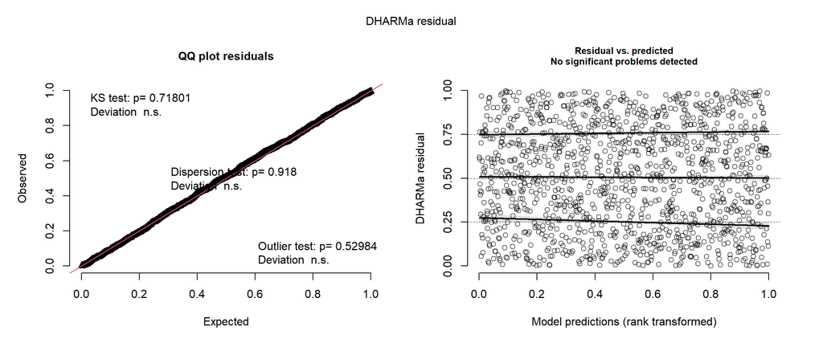

```r
residuals <- DHARMa::simulateResiduals(fit[[1]], n = 1000)

plot(residuals)
```

**Visualization**

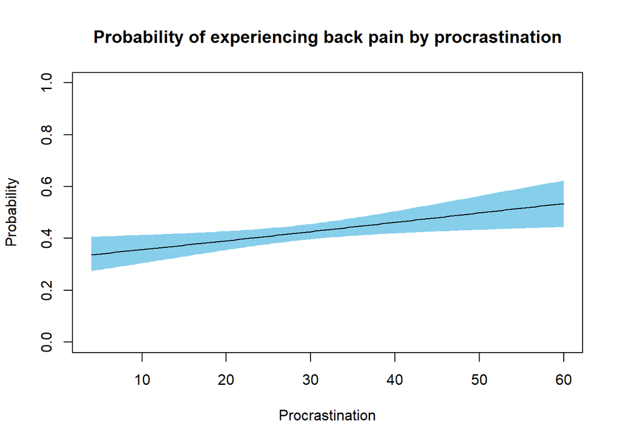

```r
plot(fit[[1]], select = 1, trans = plogis, shift = coef(fit[[1]])[1], seWithMean = TRUE,
  rug = FALSE, shade = TRUE, shade.col = "skyblue", ylim = c(0, 1),
  ylab = "Probability", xlab = "Procrastination", main = "Probability of experiencing back pain by procrastination")
```

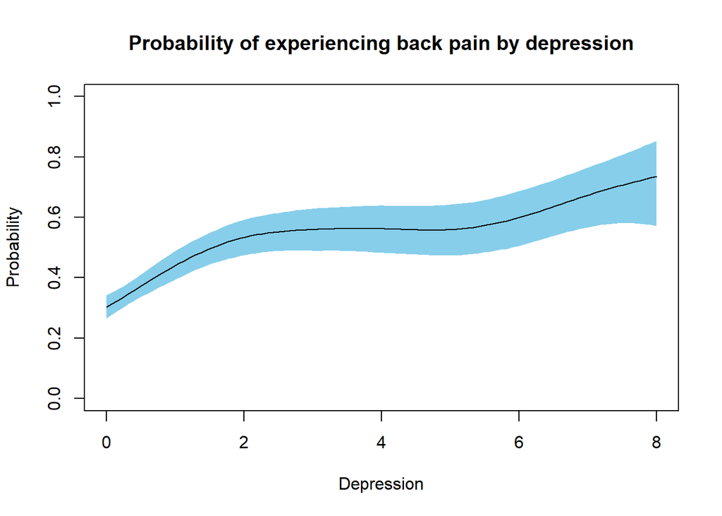

```r
plot(fit[[1]], select = 2, trans = plogis, shift = coef(fit[[1]])[1], seWithMean = TRUE,
     rug = FALSE, shade = TRUE, shade.col = "skyblue", ylim = c(0, 1),
     ylab = "Probability", xlab = "Depression", main = "Probability of experiencing back pain by depression")
```

### Headaches

**Summary**

```r
broom::tidy(fit[[2]])
```

```
# A tibble: 3 × 5
  term                       edf ref.df statistic     p.value
  <chr>                    <dbl>  <dbl>     <dbl>       <dbl>
1 s(Total_procrastination)  1.00   1.00      3.13 0.0769
2 s(Total_depression)       1.19   1.36     34.0  0.000000528
3 s(Age)                    2.37   3.05     13.8  0.00347
```

**Diagnostics**

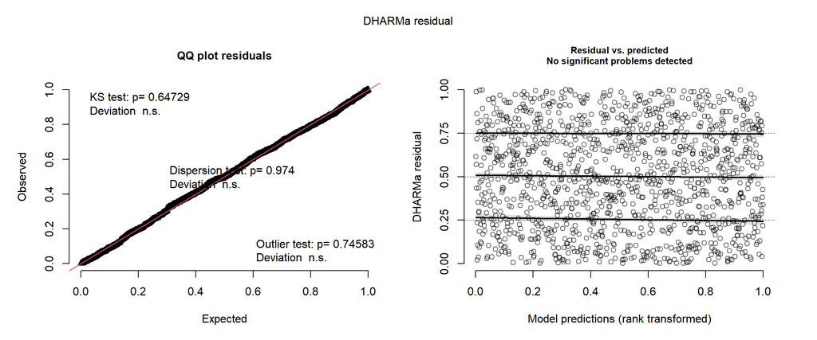

```r
residuals <- DHARMa::simulateResiduals(fit[[2]], n = 1000)

plot(residuals)
```

**Visualization**

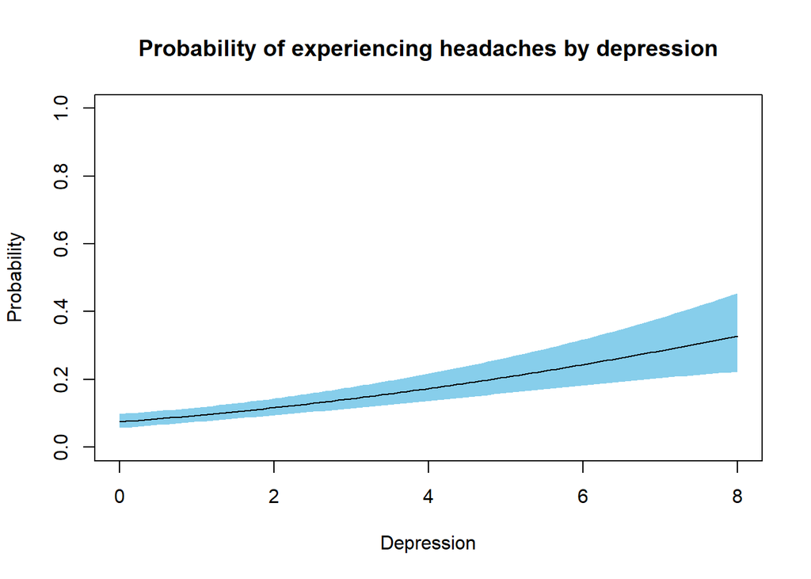

```r
plot(fit[[2]], select = 2, trans = plogis, shift = coef(fit[[2]])[1], seWithMean = TRUE,
     rug = FALSE, shade = TRUE, shade.col = "skyblue", ylim = c(0, 1),
     ylab = "Probability", xlab = "Depression", main = "Probability of experiencing headaches by depression")
```

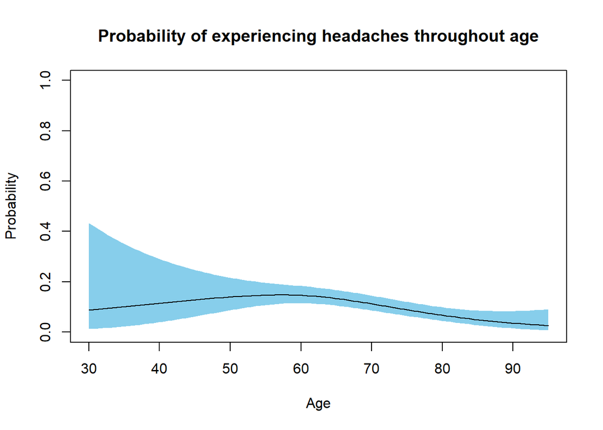

```r
plot(fit[[2]], select = 3, trans = plogis, shift = coef(fit[[2]])[1], seWithMean = TRUE,
     rug = FALSE, shade = TRUE, shade.col = "skyblue", ylim = c(0, 1),
     ylab = "Probability", xlab = "Age", main = "Probability of experiencing headaches throughout age")
```

### Fatigue

**Summary**

```r
broom::tidy(fit[[3]])
```

```
# A tibble: 3 × 5
  term                       edf ref.df statistic  p.value
  <chr>                    <dbl>  <dbl>     <dbl>    <dbl>
1 s(Total_procrastination)  2.34   2.95    20.8   0.000144
2 s(Total_depression)       3.38   4.19   122.    0
3 s(Age)                    1.62   2.05     0.784 0.687
```

**Diagnostics**

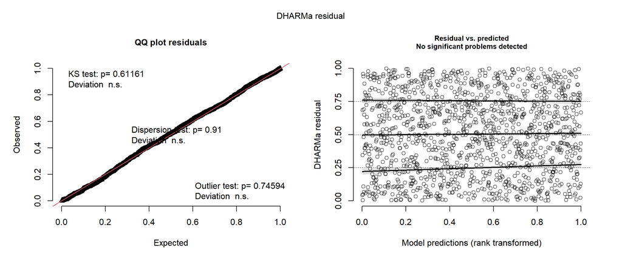

```r
residuals <- DHARMa::simulateResiduals(fit[[3]], n = 1000)

plot(residuals)
```

**Visualization**

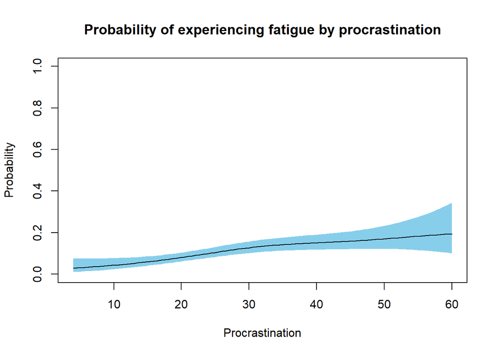

```r
plot(fit[[3]], select = 1, trans = plogis, shift = coef(fit[[3]])[1], seWithMean = TRUE,
     rug = FALSE, shade = TRUE, shade.col = "skyblue", ylim = c(0, 1),
     ylab = "Probability", xlab = "Procrastination", main = "Probability of experiencing fatigue by procrastination")
```

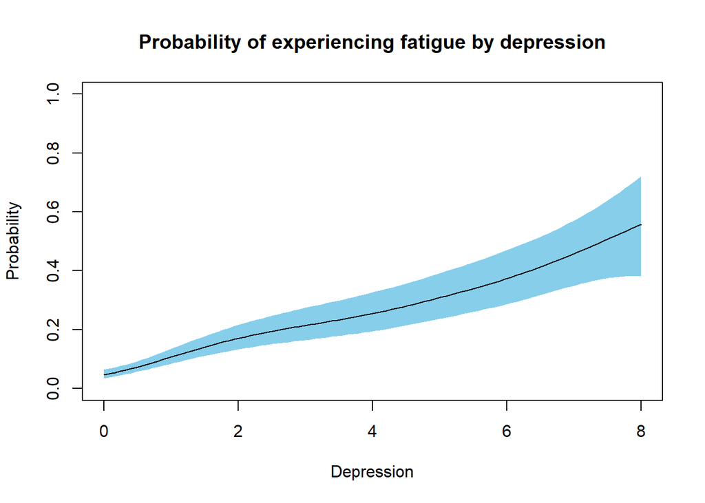

```r
plot(fit[[3]], select = 2, trans = plogis, shift = coef(fit[[3]])[1], seWithMean = TRUE,
     rug = FALSE, shade = TRUE, shade.col = "skyblue", ylim = c(0, 1),
     ylab = "Probability", xlab = "Depression", main = "Probability of experiencing fatigue by depression")
```

### Smoking

**Summary**

```r
broom::tidy(fit[[4]])
```

```
# A tibble: 3 × 5
  term                       edf ref.df statistic p.value
  <chr>                    <dbl>  <dbl>     <dbl>   <dbl>
1 s(Total_procrastination)  1.00   1.00      1.20  0.273
2 s(Total_depression)       1.64   2.03      5.72  0.0580
3 s(Age)                    2.16   2.78     39.5   0
```

**Diagnostics**

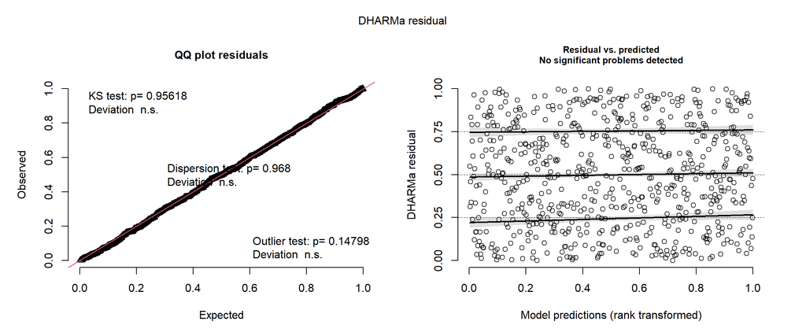

```r
residuals <- DHARMa::simulateResiduals(fit[[4]], n = 1000)

plot(residuals)
```

**Visualization**

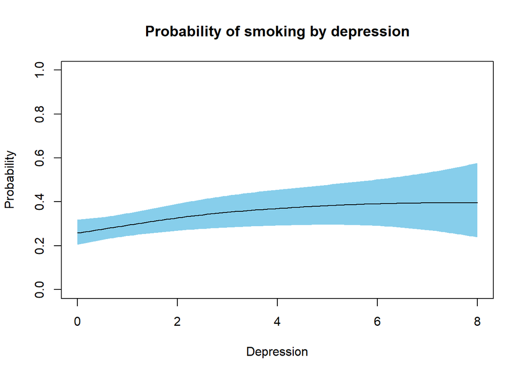

```r
plot(fit[[4]], select = 2, trans = plogis, shift = coef(fit[[4]])[1], seWithMean = TRUE,
     rug = FALSE, shade = TRUE, shade.col = "skyblue", ylim = c(0, 1),
     ylab = "Probability", xlab = "Depression", main = "Probability of smoking by depression")
```

### Blood Pressure

**Summary**

```r
broom::tidy(fit[[5]])
```

```
# A tibble: 3 × 5
  term                       edf ref.df statistic p.value
  <chr>                    <dbl>  <dbl>     <dbl>   <dbl>
1 s(Total_procrastination)  1.00   1.00      6.79 0.00920
2 s(Total_depression)       2.39   2.96     13.5  0.00390
3 s(Age)                    2.48   3.17     74.7  0
```

**Diagnostics**

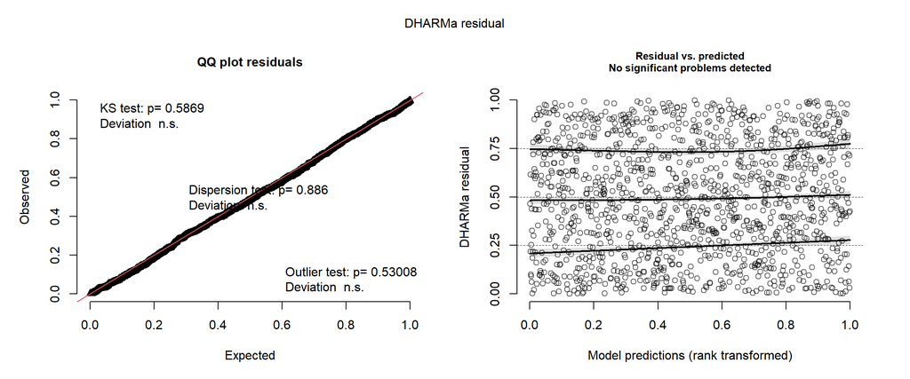

```r
residuals <- DHARMa::simulateResiduals(fit[[5]], n = 1000)

plot(residuals)
```

**Visualization**

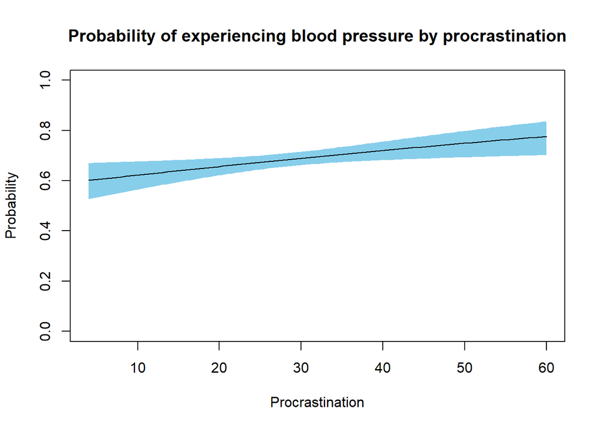

```r
plot(fit[[5]], select = 1, trans = plogis, shift = coef(fit[[5]])[1], seWithMean = TRUE,
     rug = FALSE, shade = TRUE, shade.col = "skyblue", ylim = c(0, 1),
     ylab = "Probability", xlab = "Procrastination", main = "Probability of experiencing blood pressure by procrastination")
```

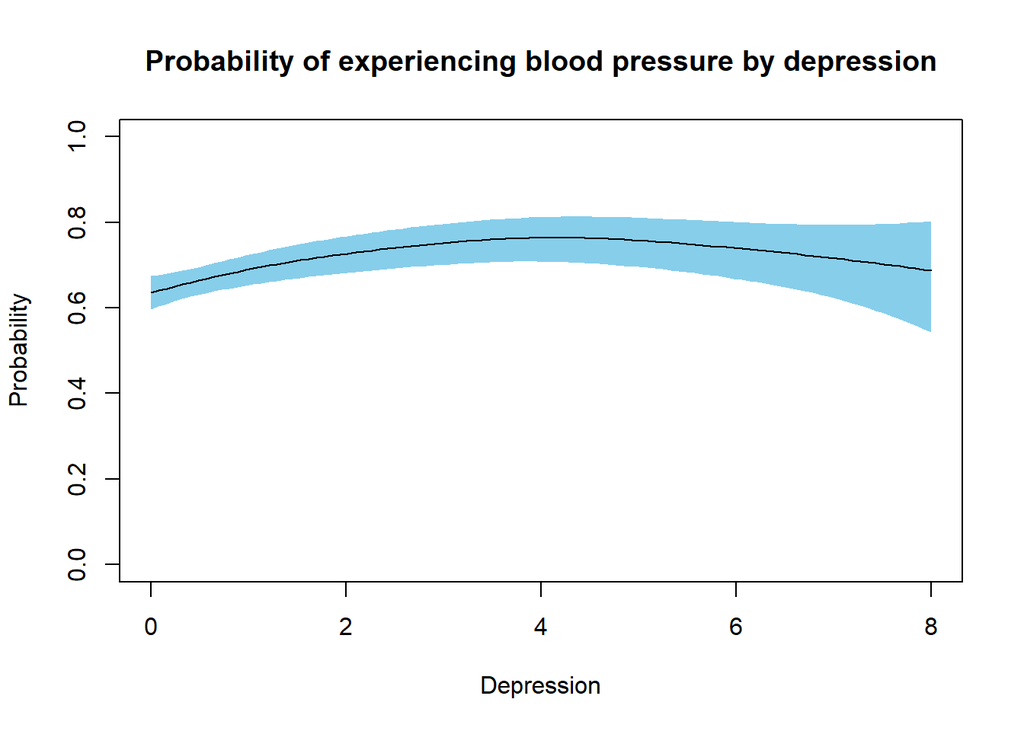

```r
plot(fit[[5]], select = 2, trans = plogis, shift = coef(fit[[5]])[1], seWithMean = TRUE,
     rug = FALSE, shade = TRUE, shade.col = "skyblue", ylim = c(0, 1),
     ylab = "Probability", xlab = "Depression", main = "Probability of experiencing blood pressure by depression")
```

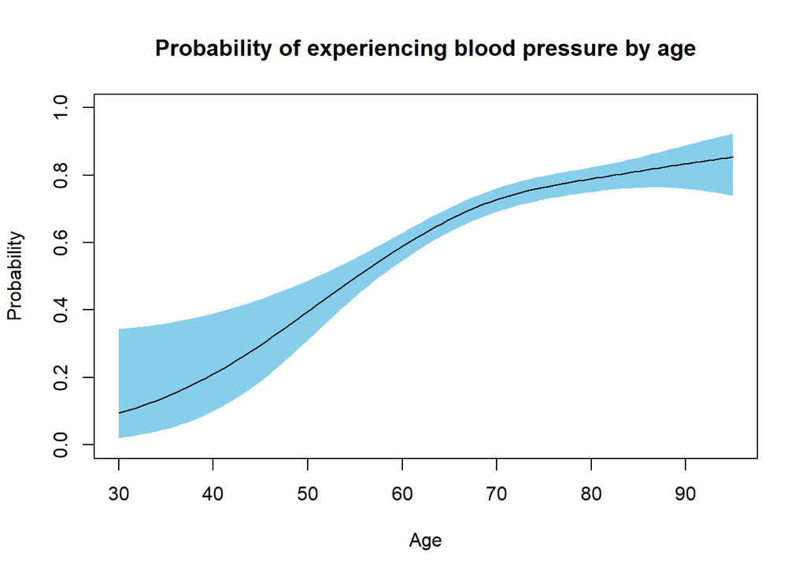

```r
plot(fit[[5]], select = 3, trans = plogis, shift = coef(fit[[5]])[1], seWithMean = TRUE,
     rug = FALSE, shade = TRUE, shade.col = "skyblue", ylim = c(0, 1),
     ylab = "Probability", xlab = "Age", main = "Probability of experiencing blood pressure by age")
```

### Diabetes

**Summary**

```r
broom::tidy(fit[[6]])
```

```
# A tibble: 3 × 5
  term                       edf ref.df statistic      p.value
  <chr>                    <dbl>  <dbl>     <dbl>        <dbl>
1 s(Total_procrastination)  1.00   1.01   27.4    0.0000000383
2 s(Total_depression)       1.00   1.00    0.0325 0.858
3 s(Age)                    2.78   3.54   10.9    0.0201
```

**Diagnostics**

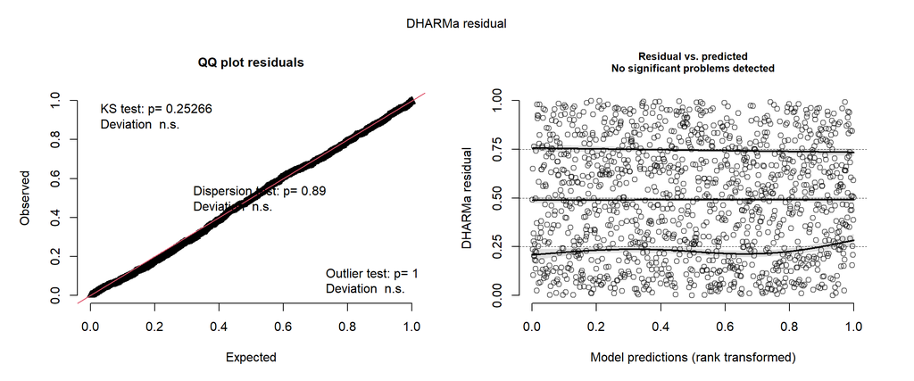

```r
residuals <- DHARMa::simulateResiduals(fit[[6]], n = 1000)

plot(residuals)
```

**Visualization**

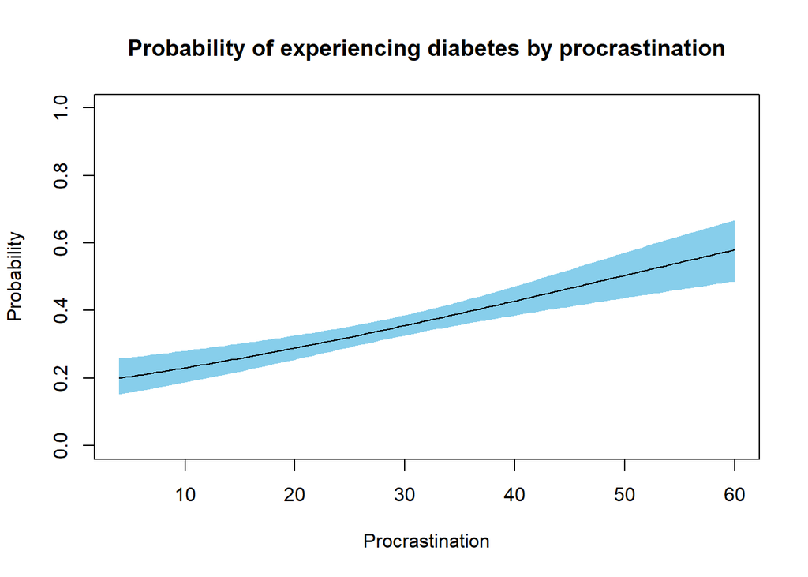

```r
plot(fit[[6]], select = 1, trans = plogis, shift = coef(fit[[6]])[1], seWithMean = TRUE,
     rug = FALSE, shade = TRUE, shade.col = "skyblue", ylim = c(0, 1),
     ylab = "Probability", xlab = "Procrastination", main = "Probability of experiencing diabetes by procrastination")
```

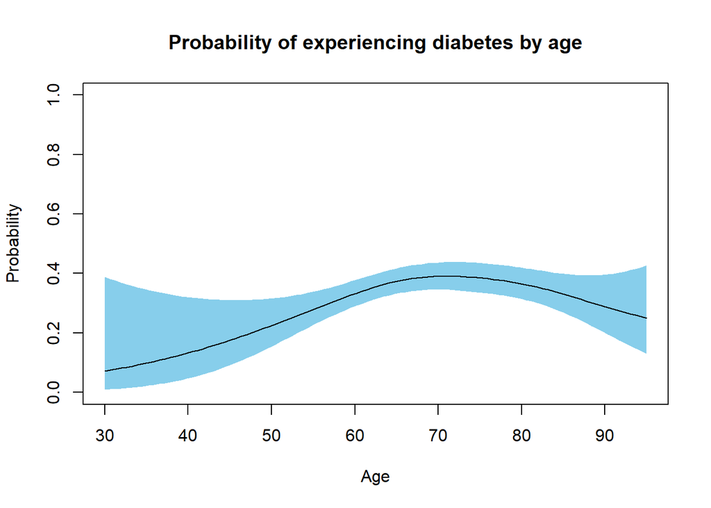

```r
plot(fit[[6]], select = 3, trans = plogis, shift = coef(fit[[6]])[1], seWithMean = TRUE,
     rug = FALSE, shade = TRUE, shade.col = "skyblue", ylim = c(0, 1),
     ylab = "Probability", xlab = "Age", main = "Probability of experiencing diabetes by age")
```

### Cholesterol

**Summary**

```r
broom::tidy(fit[[7]])
```

```
# A tibble: 3 × 5
  term                       edf ref.df statistic p.value
  <chr>                    <dbl>  <dbl>     <dbl>   <dbl>
1 s(Total_procrastination)  1.00   1.00     0.495  0.482
2 s(Total_depression)       1.86   2.31     8.46   0.0218
3 s(Age)                    2.73   3.49     6.21   0.138
```

**Diagnostics**

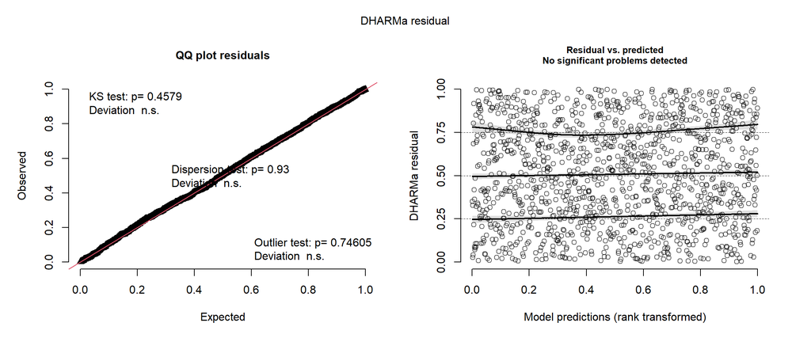

```r
residuals <- DHARMa::simulateResiduals(fit[[7]], n = 1000)

plot(residuals)
```

**Visualization**

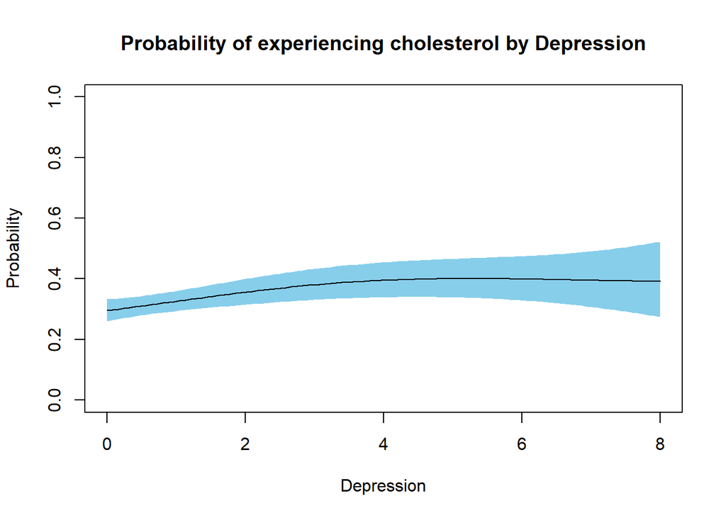

```r
plot(fit[[7]], select = 2, trans = plogis, shift = coef(fit[[7]])[1], seWithMean = TRUE,
     rug = FALSE, shade = TRUE, shade.col = "skyblue", ylim = c(0, 1),
     ylab = "Probability", xlab = "Depression", main = "Probability of experiencing cholesterol by Depression")
```

### Heart Condition

**Summary**

```r
broom::tidy(fit[[8]])
```

```
# A tibble: 3 × 5
  term                       edf ref.df statistic p.value
  <chr>                    <dbl>  <dbl>     <dbl>   <dbl>
1 s(Total_procrastination)  1.26   1.48     0.367 0.621
2 s(Total_depression)       1.00   1.00     8.24  0.00411
3 s(Age)                    1.00   1.00    80.4   0
```

**Diagnostics**

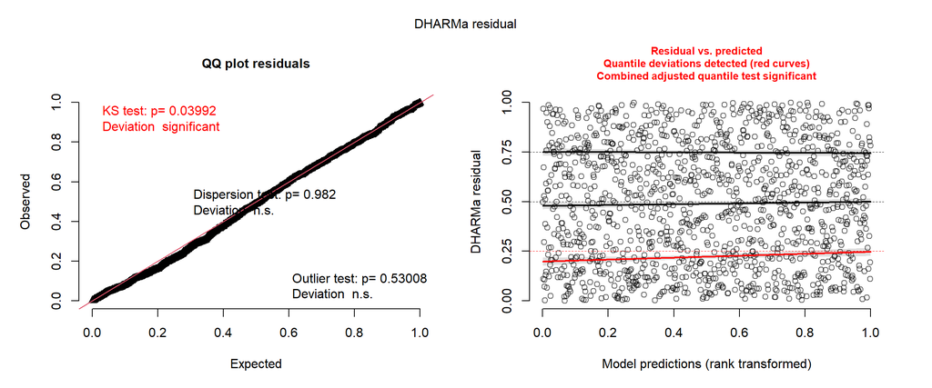

```r
residuals <- DHARMa::simulateResiduals(fit[[8]], n = 1000)

plot(residuals)
```

### Table Output (Education)

```r
sjPlot::tab_model(
  fit[[1]], fit[[2]], fit[[3]], fit[[4]],
  fit[[5]], fit[[6]], fit[[7]], fit[[8]],
  show.intercept = FALSE, show.r2 = FALSE,
  terms = c("Education"),
  title = "Generalised Additive Model Output for Education"
)
```

Generalised Additive Model Output for Education

|  | Back pain |  |  | Headache |  |  | Fatigue |  |  | Smoker current |  |  | Blood pressure |  |  | Diabetes |  |  | Cholesterol |  |  | Heart condition |  |  |
| --- | --- | --- | --- | --- | --- | --- | --- | --- | --- | --- | --- | --- | --- | --- | --- | --- | --- | --- | --- | --- | --- | --- | --- | --- |
| Predictors | Odds Ratios | CI | p | Odds Ratios | CI | p | Odds Ratios | CI | p | Odds Ratios | CI | p | Odds Ratios | CI | p | Odds Ratios | CI | p | Odds Ratios | CI | p | Odds Ratios | CI | p |
| Education | 0.96 | 0.89 – 1.04 | 0.354 | 0.87 | 0.76 – 0.99 | **0.038** | 1.08 | 0.97 – 1.20 | 0.157 | 0.76 | 0.66 – 0.88 | **<0.001** | 0.89 | 0.83 – 0.97 | **0.005** | 0.86 | 0.79 – 0.93 | **<0.001** | 0.92 | 0.85 – 1.00 | **0.044** | 0.98 | 0.90 – 1.08 | 0.733 |
| Observations | 1273 |  |  | 1275 |  |  | 1276 |  |  | 662 |  |  | 1280 |  |  | 1280 |  |  | 1277 |  |  | 1280 |  |  |

## Health Protection

As previously mentioned, some of the health protection variables have interaction effects and as such will be appropriately defined with a **tensor product smooth** in the `gam()` function. For those variables without a interaction effects the same GAM formula as the health problems will be applied.

### Prostate Exam (Interaction Present)

$$logit(p) = \beta_0 + \beta_1Education + f_1(Age) + f_2(Procrastination, Depression)$$

**Summary**

```r
prosate_fit <- gam(
  Prostate_exam ~ Education + s(Age) + te(Total_procrastination, Total_depression),
  data = health_data, family = "binomial", method = "REML")

broom::tidy(prosate_fit)
```

```
# A tibble: 2 × 5
  term                                         edf ref.df statistic p.value
  <chr>                                      <dbl>  <dbl>     <dbl>   <dbl>
1 s(Age)                                      2.94   3.70     16.1  0.00248
2 te(Total_procrastination,Total_depression)  3.60   4.02      7.32 0.122
```

**Diagnostics**

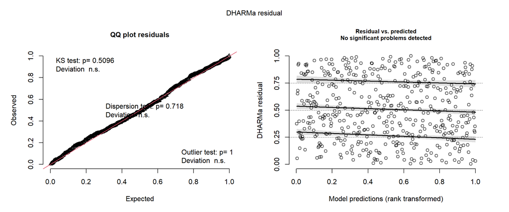

```r
residuals <- DHARMa::simulateResiduals(prosate_fit, n = 1000)
plot(residuals)
```

**Visualizing**

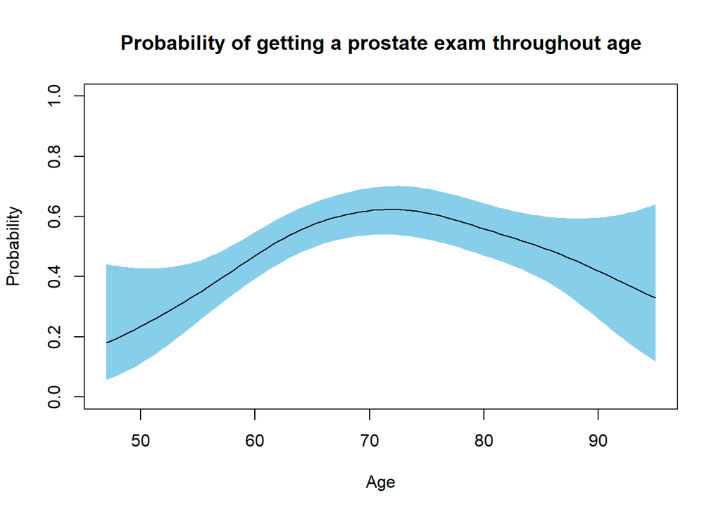

```r
plot(prosate_fit, select = 1, trans = plogis, shift = coef(prosate_fit)[1],
     seWithMean = TRUE, rug = FALSE, shade = TRUE, shade.col = "skyblue", ylim = c(0, 1),
     ylab = "Probability", main = "Probability of getting a prostate exam throughout age")
```

The probability of getting a prostate exam varies with age, following a quadratic pattern. It increases until it reaches a peak at around 70-75 years old, and then it declines. This is most likely because most health professionals advise against prostate exams for men older than 70-75, as they are unlikely to benefit from curative treatment if they have prostate cancer [(Lima et al., 2008)](https://www.ncbi.nlm.nih.gov/pmc/articles/PMC2692165/).

Different countries and organizations have different guidelines for prostate screening. In the United States, both the American Cancer Society and American Urologic Association recommend that men over 50 should get regular prostate exams. Beyond the age of 70-75, practitioners tend to then perform exams based on “patient preferences, life expectancy, health status, and prior screening history” [(Wolf et el., 2018)](https://acsjournals.onlinelibrary.wiley.com/doi/full/10.3322/caac.21457).

```r
# Depression and Procrastination
# knitr::include_graphics(here::here(path_graphics, "01__Prostate_GAM.png"))
```

### Mammogram (No Interaction)

**Summary**

```r
mammogram_fit <- gam(
  Mammogram ~ s(Total_procrastination) + s(Total_depression, k = 9) + s(Age) + Education,
  data = health_data, family = "binomial", method = "REML")

broom::tidy(mammogram_fit)
```

```
# A tibble: 3 × 5
  term                       edf ref.df statistic p.value
  <chr>                    <dbl>  <dbl>     <dbl>   <dbl>
1 s(Total_procrastination)  1.00   1.00     1.66    0.197
2 s(Total_depression)       1.00   1.00     0.922   0.337
3 s(Age)                    3.68   4.61    47.6     0
```

**Diagnostics**

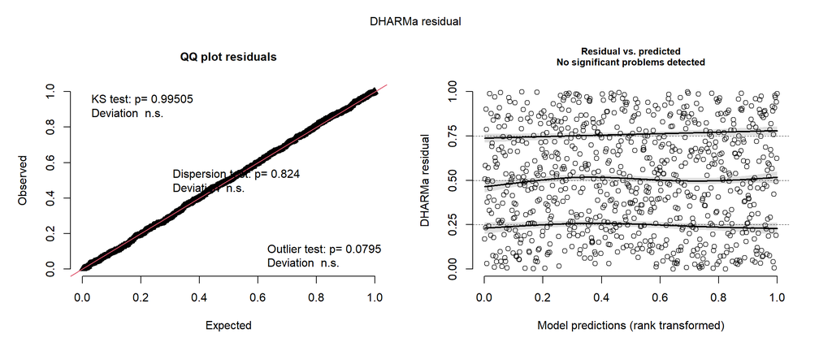

```r
residuals <- DHARMa::simulateResiduals(mammogram_fit, n = 1000)
plot(residuals)
```

**Visualizing**

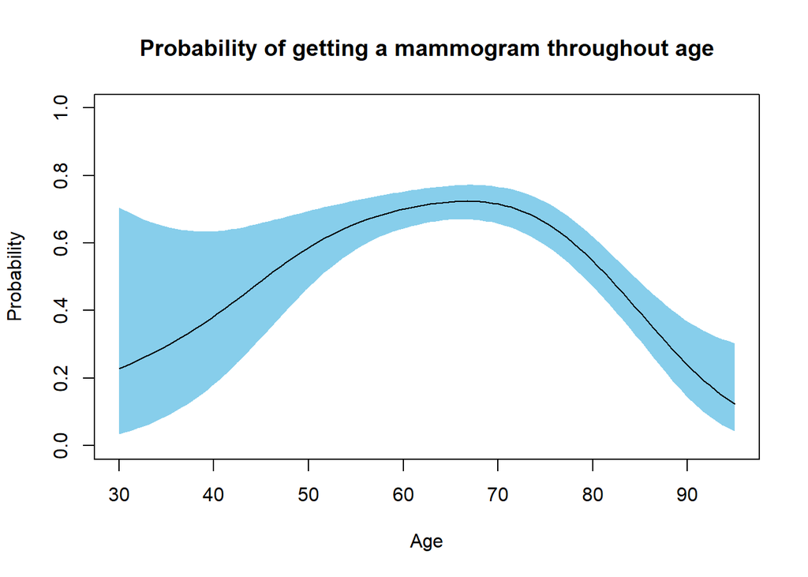

```r
plot(mammogram_fit, select = 3, trans = plogis, shift = coef(mammogram_fit)[1],
     seWithMean = TRUE, rug = FALSE, shade = TRUE, shade.col = "skyblue", ylim = c(0, 1),
     ylab = "Probability", main = "Probability of getting a mammogram throughout age")
```

Similar to prostate exams, the relationship between age and mammograms follow a quadratic relationship, increasing in probability up until the age of approximately 70 before declining. Reasons for this are also similar to that of prostate exams with clinicians recommending to stop screening for breast cancer in older age, as the benefits may not outweigh the harms [(Walter and Schonberg, 2014)](https://jamanetwork.com/journals/jama/article-abstract/1853134).

### Pap Smear (Interaction Present)

$$logit(p) = \beta_0 + \beta_1Education + f_1Procrastination + f_2(Depression, Age)$$

**Summary**

```r
pap_fit <- gam(
  Pap_smear ~ Education + s(Total_procrastination) + te(Total_depression, Age),
  data = health_data, family = "binomial", method = "REML")

broom::tidy(pap_fit)
```

```
# A tibble: 2 × 5
  term                       edf ref.df statistic p.value
  <chr>                    <dbl>  <dbl>     <dbl>   <dbl>
1 s(Total_procrastination)  1.00   1.00      1.50   0.221
2 te(Total_depression,Age)  4.99   5.96     92.1    0
```

**Diagnostics**

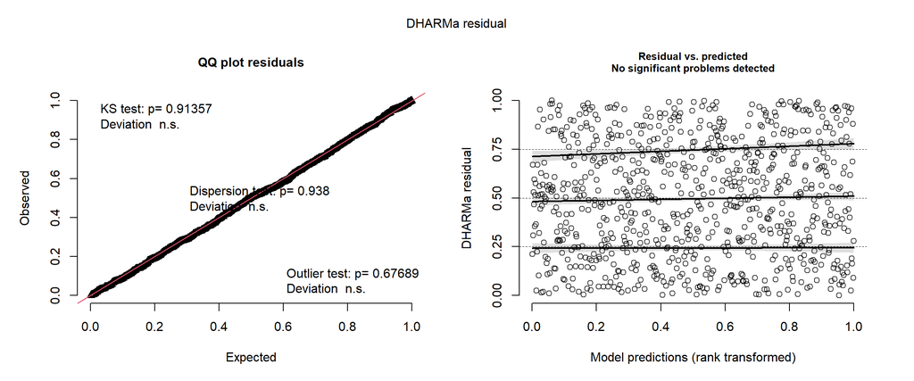

```r
residuals <- DHARMa::simulateResiduals(pap_fit, n = 1000)
plot(residuals)
```

**Visualizing**

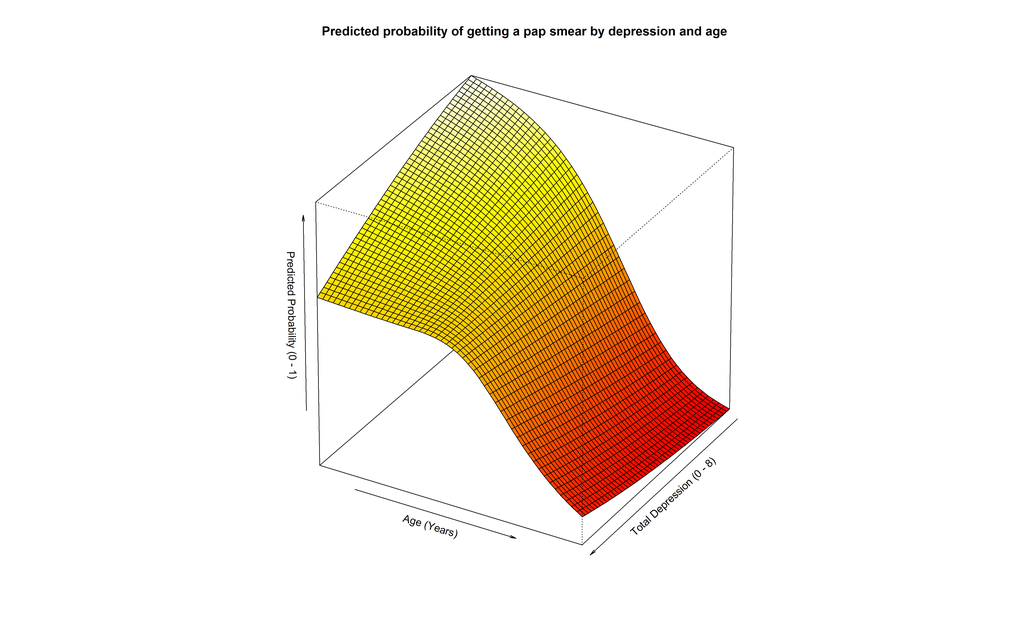

```r
knitr::include_graphics(here::here(path_graphics, "02__Pap_Smear_GAM.png"))
```

Following the directionality of the x, y, and z axes, the `vis.gam()` contour plot shows that the probability of getting a pap smear depends on both age and depression. For younger individuals, lower levels of depression are associated with a higher probability of getting a pap smear, while higher levels of depression are associated with a lower probability. However, as age increases the probability of getting a pap smear also begins to decrease regardless of depression score.

### Flu Shot (No Interaction)

**Summary**

```r
flu_fit <- gam(
  Flu_shot ~ s(Total_procrastination) + s(Total_depression, k = 9) + s(Age) + Education,
  data = health_data, family = "binomial", method = "REML")

broom::tidy(flu_fit)
```

```
# A tibble: 3 × 5
  term                       edf ref.df statistic p.value
  <chr>                    <dbl>  <dbl>     <dbl>   <dbl>
1 s(Total_procrastination)  1.00   1.00  0.000185   0.996
2 s(Total_depression)       1.20   1.37  0.0567     0.886
3 s(Age)                    1.00   1.00 81.4        0
```

**Diagnostics**

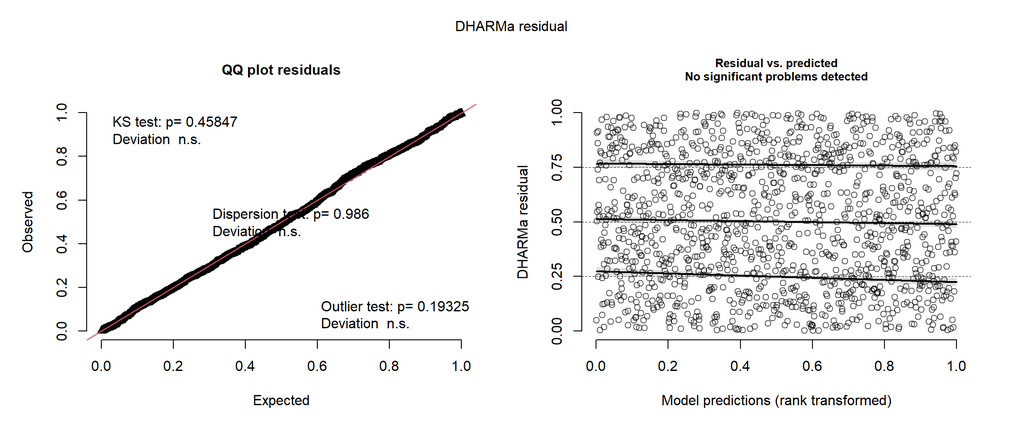

```r
residuals <- DHARMa::simulateResiduals(flu_fit, n = 1000)
plot(residuals)
```

**Visualizing**

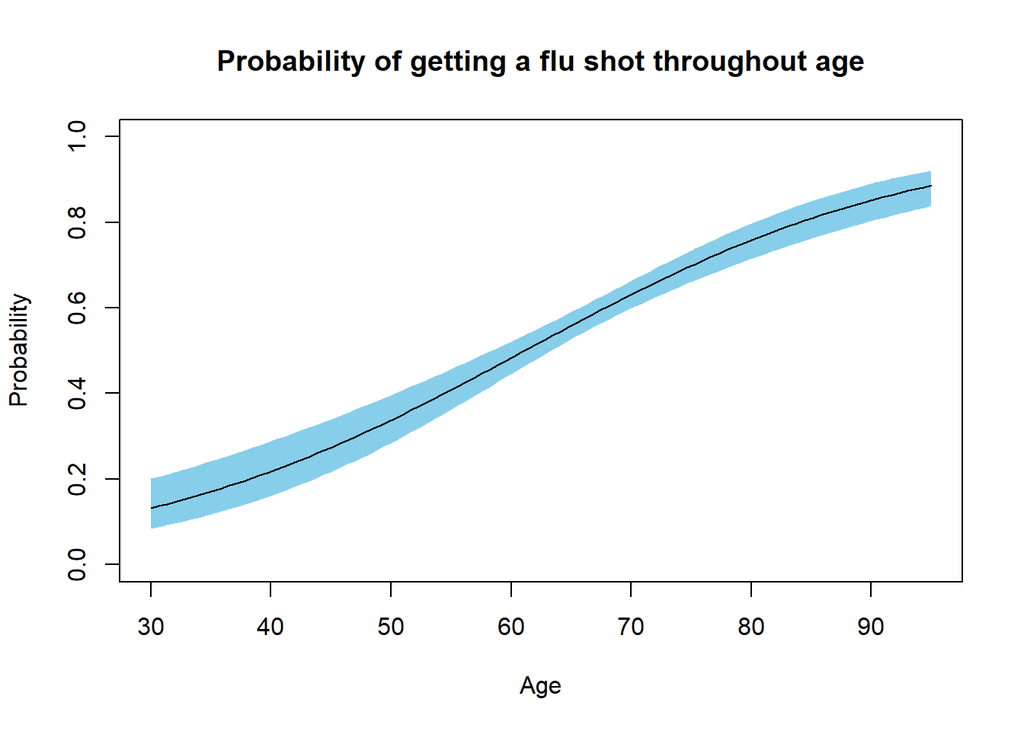

```r
plot(flu_fit, select = 3, trans = plogis, shift = coef(flu_fit)[1],
     seWithMean = TRUE, rug = FALSE, shade = TRUE, shade.col = "skyblue", ylim = c(0, 1),
     ylab = "Probability", main = "Probability of getting a flu shot throughout age")
```

### Dental Visit (Interaction)

$$logit(p) = \beta_0 + \beta_1Education + f_1Depression + f_2(Procrastination, Age)$$
**Summary**

```r
dentist_fit <- gam(
  Dental_visit_2_years ~ Education + s(Total_depression, k = 9) + te(Total_procrastination, Age),
  data = health_data, family = "binomial", method = "REML")

broom::tidy(dentist_fit)
```

```
# A tibble: 2 × 5
  term                            edf ref.df statistic p.value
  <chr>                         <dbl>  <dbl>     <dbl>   <dbl>
1 s(Total_depression)            1.55   1.91     0.845  0.574
2 te(Total_procrastination,Age)  5.10   6.40    12.0    0.0719
```

**Diagnostics**

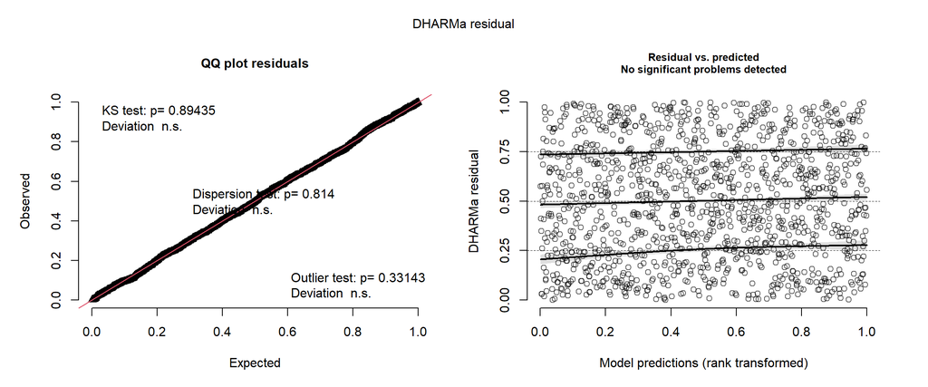

```r
residuals <- DHARMa::simulateResiduals(dentist_fit, n = 1000)
plot(residuals)
```

**Visualizing**

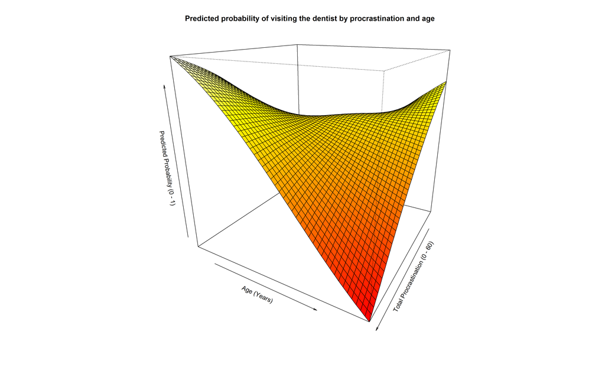

```r
knitr::include_graphics(here::here(path_graphics, "03__Dentist_GAM.png"))
```

Again, following the directionality of the x, y, and z axes, the `vis.gam()` contour plot shows that the probability of visiting the dentist depends on both age and procrastination. For younger individuals, higher levels of procrastination is associated with a higher probability of visiting the dentist, while lower levels of procrastination is associated with a lower probability. This increased probability for higher levels of procrastination may be seen as mandatory unavoidable visits due to the procrastination of at home dental care. As age then increases the probability of visiting the dentist increases for those with low levels of procrastination and decreases for those with high levels of procrastination.